# Project1

Rangers

October 15, 2016

```r
library(dplyr)
```

```r
library(plotly)
library(ggplot2)
library(Ecdat)
library(caTools)
library(mypackage)
library(leaps)
library(ROCR)
data("MedExp")
```

changing the target numerical variable to a categorical variable

```r
MedExp$medCategory=ifelse(MedExp$med>median(MedExp$med),0,1)
```

# plotting a linear model with age, with polynomial degree of 3

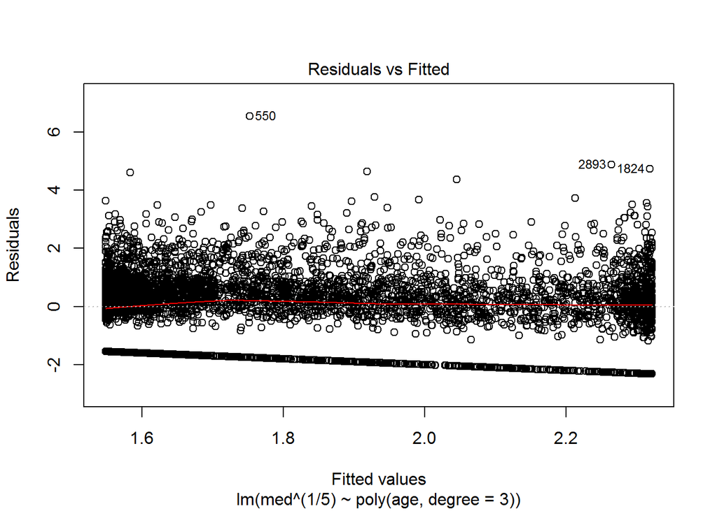

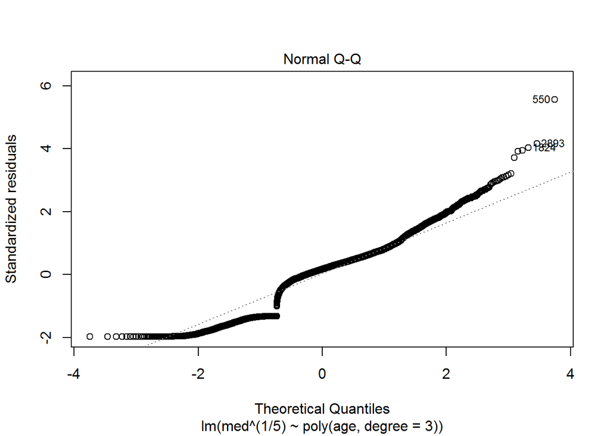

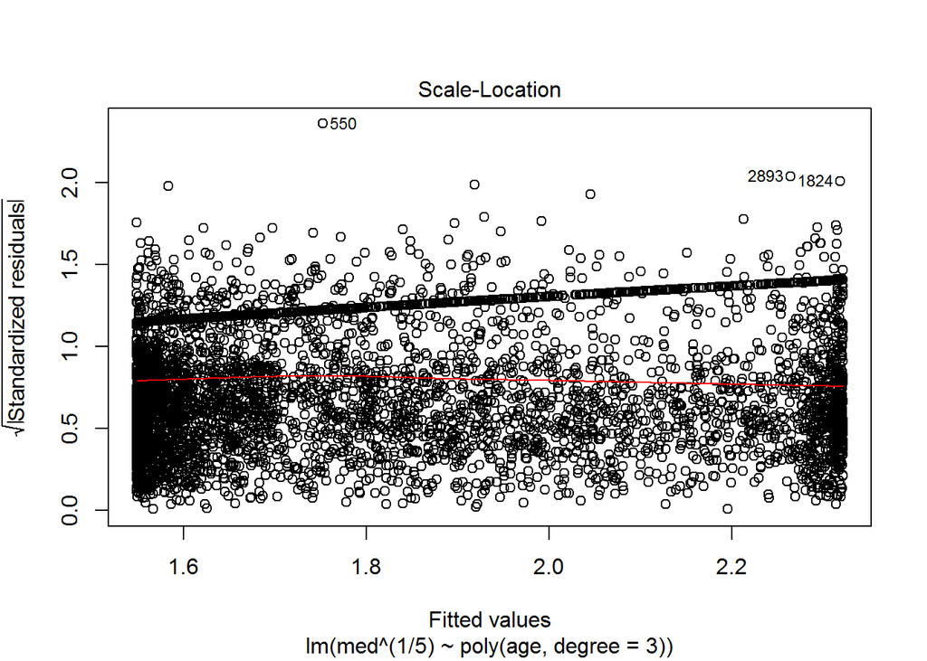

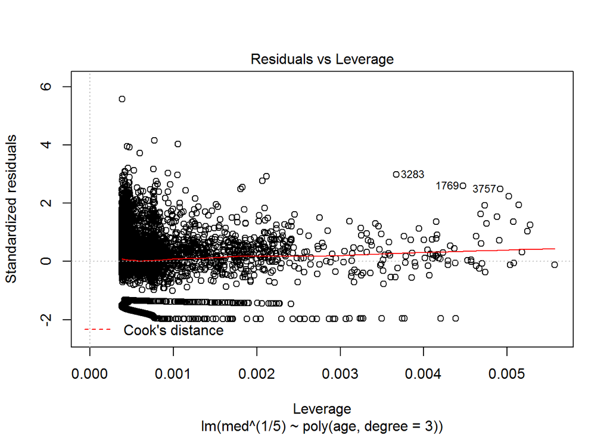

```r
linearModel=lm(med^(1/5)~poly(age,degree = 3),data = MedExp[,-16])
plot(linearModel)
```

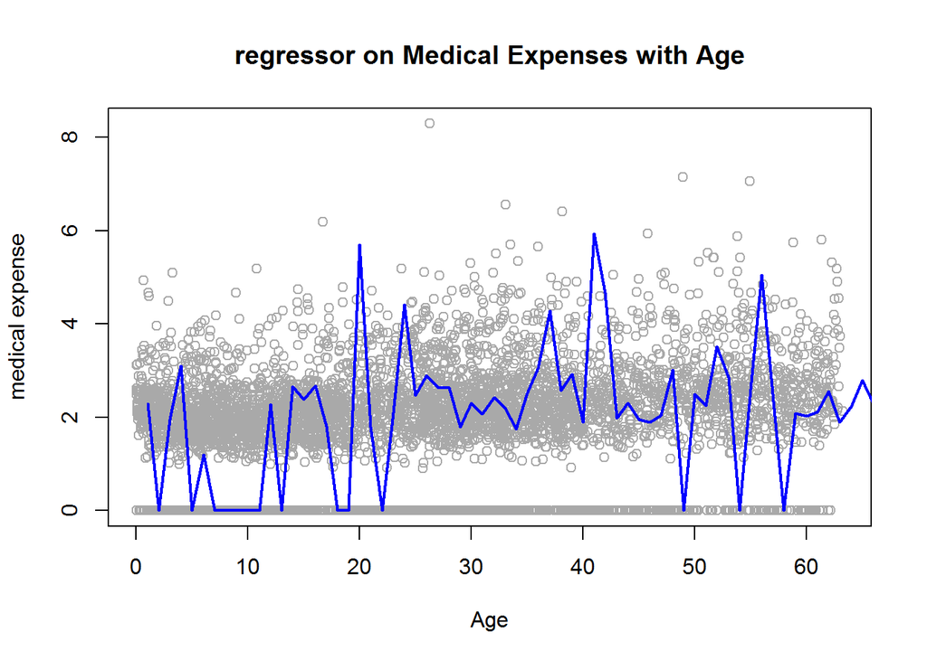

```r
predictMed=predict(linearModel,data=MedExp[,-16],se=T)
se.bands=cbind(predictMed$fit+2*predictMed$se,predictMed$fit-2*predictMed$se)
plot(MedExp$age,MedExp$med^(1/5),col='darkgrey',xlab="Age",ylab="medical expense",main="regressor on Medical Expenses with Age")
lines(MedExp$med^(1/5),MedExp$fit,lwd=2,col="blue")
```

non linearity with logistic regresion

```r
split=sample.split(MedExp$medCategory,SplitRatio = 0.4)
MedExpTrain=MedExp[split==TRUE,]
MedExpValid=MedExp[split==FALSE,]
medPolyglm=glm(medCategory~poly(age,3),data=MedExpTrain,family=binomial)
summary(medPolyglm)
```

```
##
## Call:
## glm(formula = medCategory ~ poly(age, 3), family = binomial,
##     data = MedExpTrain)
##
## Deviance Residuals:
##      Min        1Q    Median        3Q       Max
## -1.37239  -1.16008   0.05853   1.04184   1.51095
##
## Coefficients:
##                 Estimate Std. Error z value Pr(>|z|)
## (Intercept)    -0.003481   0.043344  -0.080   0.9360
## poly(age, 3)1 -19.650462   2.082956  -9.434   <2e-16 ***
## poly(age, 3)2  -1.094184   2.057644  -0.532   0.5949
## poly(age, 3)3   5.273214   2.060662   2.559   0.0105 *
## ---
## Signif. codes:  0 '***' 0.001 '**' 0.01 '*' 0.05 '.' 0.1 ' ' 1
##
## (Dispersion parameter for binomial family taken to be 1)
##
##     Null deviance: 3091.4  on 2229  degrees of freedom
## Residual deviance: 2991.7  on 2226  degrees of freedom
## AIC: 2999.7
##
## Number of Fisher Scoring iterations: 4
```

```r
agelims=range(MedExp$age)
age.grid=seq(from=agelims[1],to=agelims[2] )
predictAge=predict(medPolyglm,newdata = list(age=age.grid),se=T)
se.bands=predictAge$fit+cbind(medPolyglm=0,lower=-2*predictAge$se.fit,upper=2*predictAge$se.fit)
se.bands[1:5,]
```

```
##   medPolyglm       lower     upper
## 1  0.3047174 -0.00766905 0.6171039
## 2  0.3378246  0.06408619 0.6115630
## 3  0.3662462  0.12660259 0.6058897
## 4  0.3901376  0.17991890 0.6003563
## 5  0.4096543  0.22405930 0.5952493
```

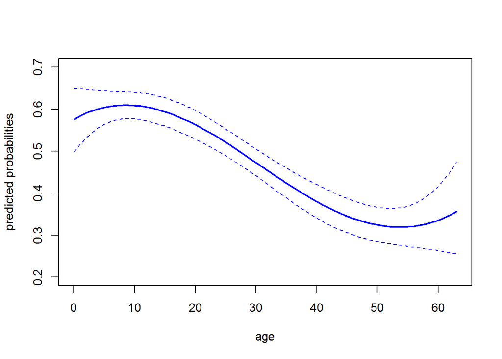

```r
prob.bands=exp(se.bands)/(1+exp(se.bands))
matplot(age.grid,prob.bands,col='blue',lwd=c(2,1,1),lty=c(1,2,2),type="l",ylim=c(0.2,.7),xlab="age",ylab="predicted probabilities")
```

predictions on actual data calling our package for computing metrics using ROCR package for computing metrics

```r
predictActual=predict(medPolyglm,newdata = MedExpValid,type="response")
confusionMetrics(MedExpValid$medCategory,predictActual,threshold = 0.5,k=1)
```

```
##       AIC       BIC       TPR       TNR       FPR       FNR Precision
##   4479.20   4493.43      0.65      0.53      0.47      0.35      0.58
##       NPV  Accuracy  FMeasure       auc
##      0.60      0.59      0.61      0.63
```

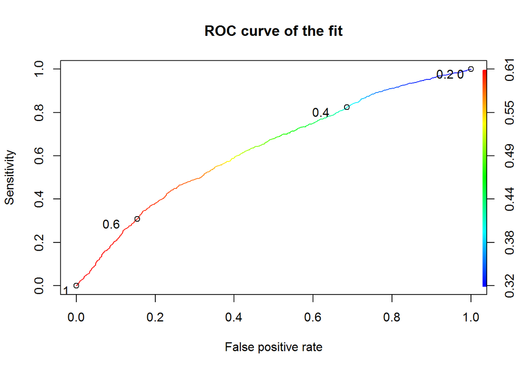

```r
#creating the prrediction object from ROCR package
predictionObject=prediction(predictActual,MedExpValid$medCategory)
performanceObject=performance(predictionObject, "sens", "fpr")
plot(performanceObject,colorize=T,print.cutoffs.at=seq(0,1,0.2),text.adj=c(2,1),main="ROC curve of the fit");
```

subset selection using leaps package

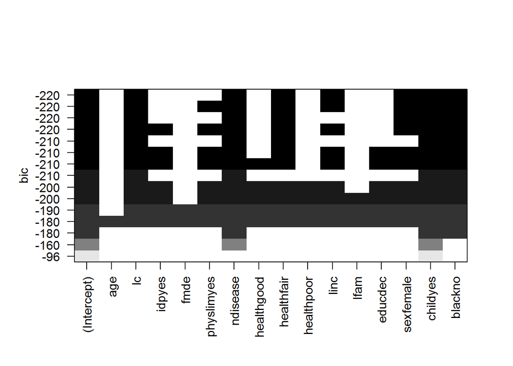

```r
medSubsets=regsubsets(medCategory~age+lc+idp+idp
                      +fmde+physlim+ndisease+health+linc+
                        +lfam+educdec+sex+child+black,
                      data = MedExpTrain,nvmax = 17,method ="forward" )
plot(medSubsets)
```

```r
summaryObject=summary(medSubsets)
names(summaryObject)
```

```
## [1] "which"  "rsq"    "rss"    "adjr2"  "cp"     "bic"    "outmat" "obj"
```

```r
summaryObject%>%plot_ly( y = cp,name="cp statistic",mode = 'markers+lines') %>%
  add_trace(y = summaryObject$bic, name = 'BIC', mode = 'markers+lines')
```

[interactive chart not shown]

model selections with lasso and ridge classifiers we pass inputs as a matrix model.matrix converts all the qualitative variables into dummy variables

```r
library(glmnet)
independentVar=model.matrix(medCategory~.-med,data = MedExp)
dependentVar=MedExp$medCategory
```

alpha=0—-> ridge regression using L2 Norm alpha=1—-> Lasso regression using L1 Norm we will use lamdba parameter as tuning parameter with a grid of values grid values from 10 power 10 to -2 standardize=TRUE automatically dimensions are parameters*grid values for lamba

```r
Lgrid=10^seq(10,-2,length=100)
ridgeModel=glmnet(independentVar,dependentVar,family = "binomial",lambda = Lgrid,alpha = 0)
dim(coef(ridgeModel))
```

```
## [1]  18 100
```

interpreting when lambda is large coefficients will be as small as they can be when lambda is small coefficients will be close to normal logistic regression

```r
ridgeModel$lambda[100]
```

```
## [1] 0.01
```

```r
coef(ridgeModel)[,100]
```

```
##  (Intercept)  (Intercept)           lc       idpyes          lpi
##  1.572919227  0.000000000  0.115913140  0.277245120 -0.022439851
##         fmde   physlimyes     ndisease   healthgood   healthfair
##  0.021386312 -0.411878943 -0.039666546 -0.228495751 -0.543676642
##   healthpoor         linc         lfam      educdec          age
## -0.806899277 -0.116680657  0.165094793 -0.038210555 -0.005515176
##    sexfemale     childyes      blackno
## -0.332610504  0.458723728  0.667166400
```

```r
#l2 norm calculation
sqrt(sum(coef(ridgeModel)[-(1:2),100])^2)
```

```
## [1] 0.8405444
```

```r
#large lambda
ridgeModel$lambda[10]
```

```
## [1] 811130831
```

```r
coef(ridgeModel)[,10]
```

```
##   (Intercept)   (Intercept)            lc        idpyes           lpi
##  5.617206e-10  0.000000e+00  4.690105e-11  1.047302e-10  5.267104e-12
##          fmde    physlimyes      ndisease    healthgood    healthfair
##  2.289141e-11 -1.890768e-10 -1.857434e-11 -7.730487e-11 -1.411085e-10
##    healthpoor          linc          lfam       educdec           age
## -2.807091e-10 -4.908004e-11  1.444518e-10 -1.487535e-11 -7.642356e-12
##     sexfemale      childyes       blackno
## -1.346602e-10  2.533067e-10  2.571303e-10
```

```r
#l2 norm calculation
sqrt(sum(coef(ridgeModel)[-(1:2),10])^2)
```

```
## [1] 7.835304e-11
```

plotting the model

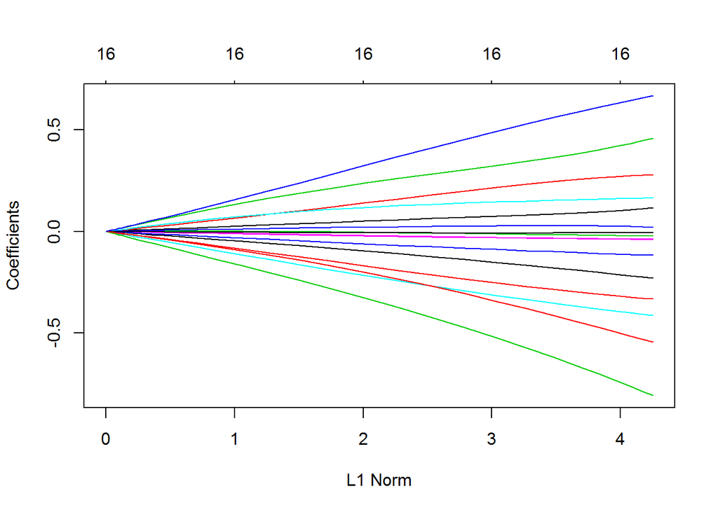

```r
plot.glmnet(ridgeModel)
```

predictions using train and validation using cross validation sample predictions on one model

```r
trainIndependentVar=model.matrix(medCategory~.-med,data = MedExpTrain)
trainDependentVar=MedExpTrain$medCategory
testIndependentVar=model.matrix(medCategory~.-med,data = MedExpValid)
testDependentVar=MedExpValid$medCategory
ridgeTrain=glmnet(trainIndependentVar,trainDependentVar,alpha = 0,lambda = Lgrid)
predictTest=predict(ridgeTrain,s = 10,newx =testIndependentVar)
confusionMetrics(target = testDependentVar,predicted =predictTest,threshold = 0.5,k = 16)
```

```
##       AIC       BIC       TPR       TNR       FPR       FNR Precision
##   4592.06   4819.74      0.66      0.62      0.38      0.34      0.64
##       NPV  Accuracy  FMeasure       auc
##      0.65      0.64      0.65      0.70
```

cross validation using ridge 10 fold cross validation by default

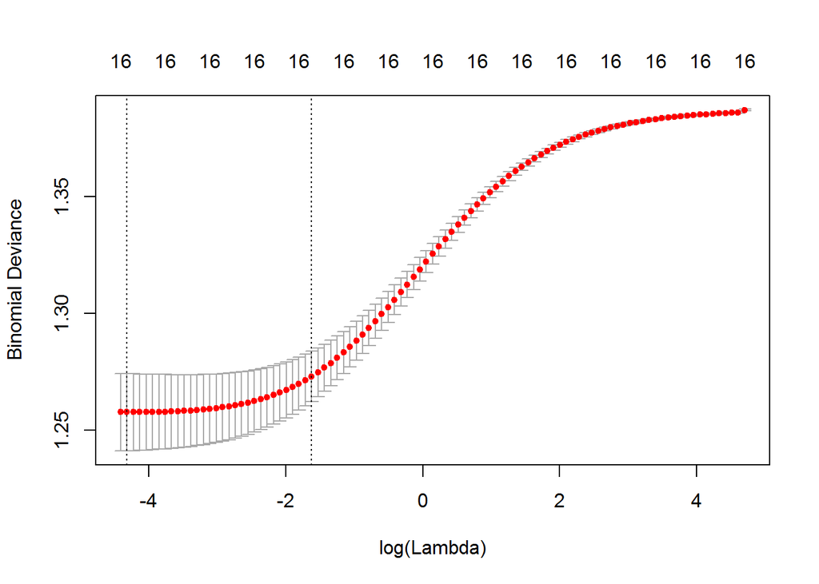

```r
cvRidgeDeviance=cv.glmnet(trainIndependentVar,trainDependentVar,family="binomial",
                  alpha=0,nfolds = 10,type.measure="deviance")
plot(cvRidgeDeviance)
```

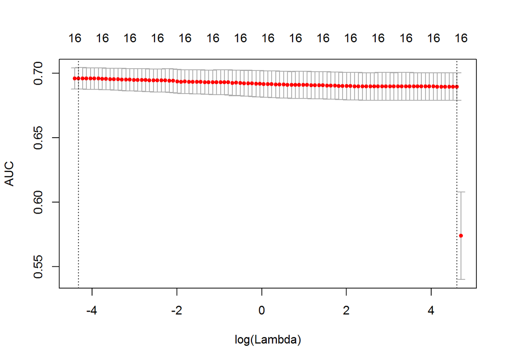

```r
cvRidgeAuc=cv.glmnet(trainIndependentVar,trainDependentVar,family="binomial",
                  alpha=0,nfolds = 10,type.measure="auc")
plot(cvRidgeAuc)
```

getting the best statistics to compute the error

```r
bestLambda=cvRidgeAuc$lambda.min
pedictCV=predict.cv.glmnet(cvRidgeAuc,s=bestLambda,
                        newx = testIndependentVar,type = "response")
confusionMetrics(target = testDependentVar,predicted =pedictCV,threshold = 0.3,k = 16)
```

```
##       AIC       BIC       TPR       TNR       FPR       FNR Precision
##   4189.86   4417.53      0.94      0.23      0.77      0.06      0.55
##       NPV  Accuracy  FMeasure       auc
##      0.80      0.58      0.69      0.71
```

```r
coef(cvRidgeAuc)
```

```
## 18 x 1 sparse Matrix of class "dgCMatrix"
##                         1
## (Intercept)  4.696790e-03
## (Intercept)  .
## lc           3.256142e-04
## idpyes       8.215360e-04
## lpi         -8.661986e-07
## fmde         1.482147e-04
## physlimyes  -1.297421e-03
## ndisease    -1.436901e-04
## healthgood  -4.906006e-04
## healthfair  -1.704258e-03
## healthpoor  -1.903231e-03
## linc        -4.185046e-04
## lfam         1.267699e-03
## educdec     -1.119974e-04
## age         -5.941025e-05
## sexfemale   -1.080033e-03
## childyes     2.216203e-03
## blackno      1.945253e-03
```

fitting lasso L1 Norm

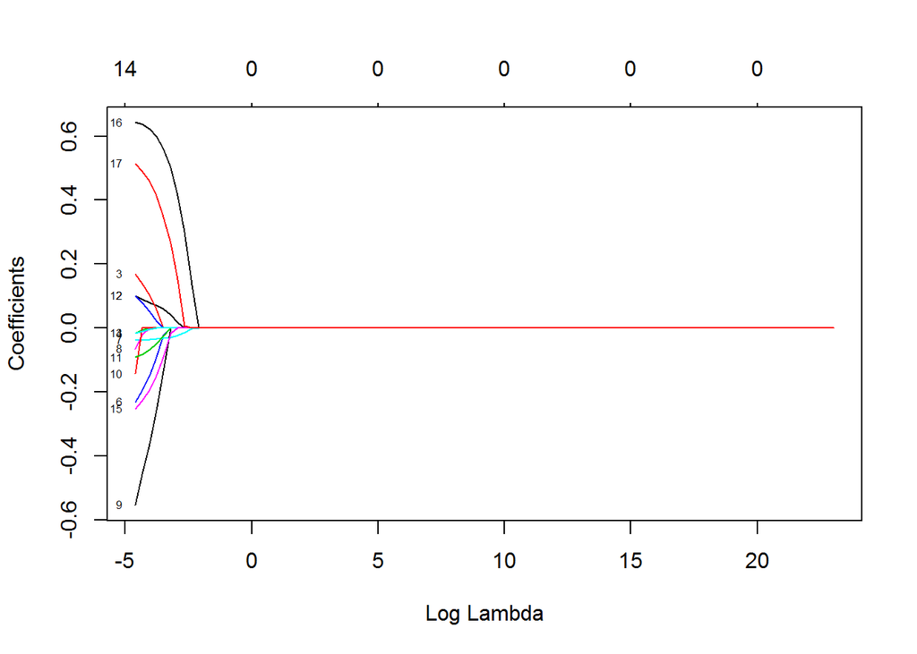

```r
lassoTrain=glmnet(trainIndependentVar,trainDependentVar,alpha = 1,lambda = Lgrid,family="binomial")
plot.glmnet(lassoTrain,xvar="lambda",type,label=TRUE)
```

```r
lassoTrain$lambda[100]
```

```
## [1] 0.01
```

```r
coef(lassoTrain)[,100]
```

```
## (Intercept) (Intercept)          lc      idpyes         lpi        fmde
##  0.95019056  0.00000000  0.10121819  0.16838455 -0.01596930  0.00000000
##  physlimyes    ndisease  healthgood  healthfair  healthpoor        linc
## -0.23139217 -0.03774744 -0.06605197 -0.55409814 -0.14338533 -0.09226021
##        lfam     educdec         age   sexfemale    childyes     blackno
##  0.10038838 -0.01647802  0.00000000 -0.25360956  0.64308525  0.51419051
```

```r
predictTest=predict(lassoTrain,s = 0.01,newx =testIndependentVar,type = "response")
confusionMetrics(target = testDependentVar,predicted =predictTest,threshold = 0.5,k = 18)
```

```
##       AIC       BIC       TPR       TNR       FPR       FNR Precision
##   4215.48   4471.62      0.66      0.62      0.38      0.34      0.64
##       NPV  Accuracy  FMeasure       auc
##      0.65      0.64      0.65      0.71
```

interpreting when lambda is large coefficients will be mostly zero when lambda is small coefficients will be close to least squares

```r
lassoTrain$lambda[100]
```

```
## [1] 0.01
```

```r
coef(lassoTrain)[,100]
```

```
## (Intercept) (Intercept)          lc      idpyes         lpi        fmde
##  0.95019056  0.00000000  0.10121819  0.16838455 -0.01596930  0.00000000
##  physlimyes    ndisease  healthgood  healthfair  healthpoor        linc
## -0.23139217 -0.03774744 -0.06605197 -0.55409814 -0.14338533 -0.09226021
##        lfam     educdec         age   sexfemale    childyes     blackno
##  0.10038838 -0.01647802  0.00000000 -0.25360956  0.64308525  0.51419051
```

```r
#1 norm calculation
sum(coef(lassoTrain)[-(1:2),100])
```

```
## [1] 0.1162747
```

```r
#large lambda
lassoTrain$lambda[10]
```

```
## [1] 811130831
```

```r
coef(lassoTrain)[,10]
```

```
##  (Intercept)  (Intercept)           lc       idpyes          lpi
## -6.80879e-17  0.00000e+00  0.00000e+00  0.00000e+00  0.00000e+00
##         fmde   physlimyes     ndisease   healthgood   healthfair
##  0.00000e+00  0.00000e+00  0.00000e+00  0.00000e+00  0.00000e+00
##   healthpoor         linc         lfam      educdec          age
##  0.00000e+00  0.00000e+00  0.00000e+00  0.00000e+00  0.00000e+00
##    sexfemale     childyes      blackno
##  0.00000e+00  0.00000e+00  0.00000e+00
```

```r
#l2 norm calculation
coef(lassoTrain)[-(1:2),10]
```

```
##         lc     idpyes        lpi       fmde physlimyes   ndisease
##          0          0          0          0          0          0
## healthgood healthfair healthpoor       linc       lfam    educdec
##          0          0          0          0          0          0
##        age  sexfemale   childyes    blackno
##          0          0          0          0
```

cross validation using lasso 10 fold cross validation by default

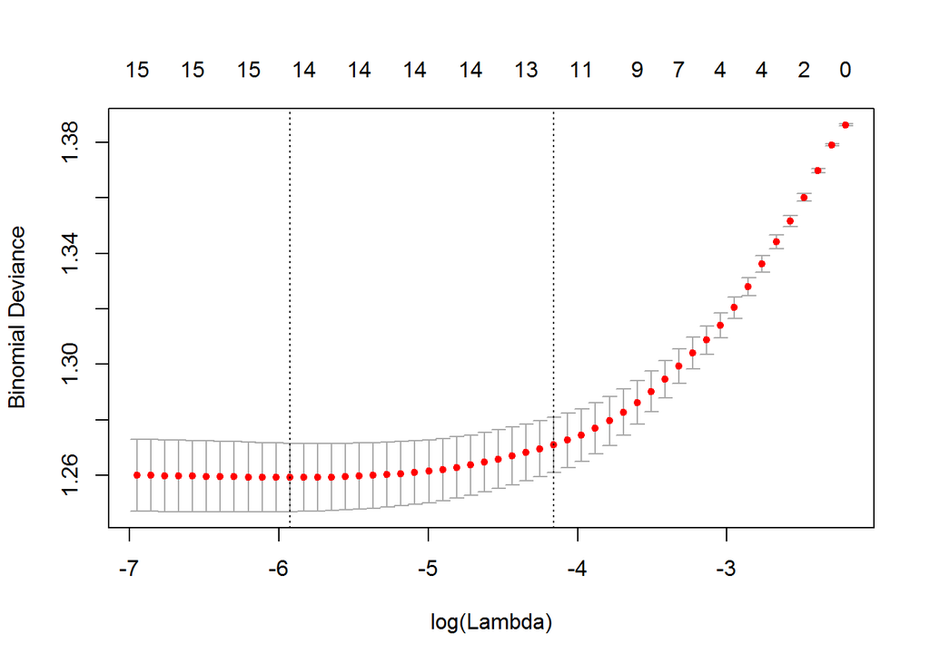

```r
cvLassoDeviance=cv.glmnet(trainIndependentVar,trainDependentVar,family="binomial",
                  alpha=1,nfolds = 10,type.measure="deviance")
plot(cvLassoDeviance)
```

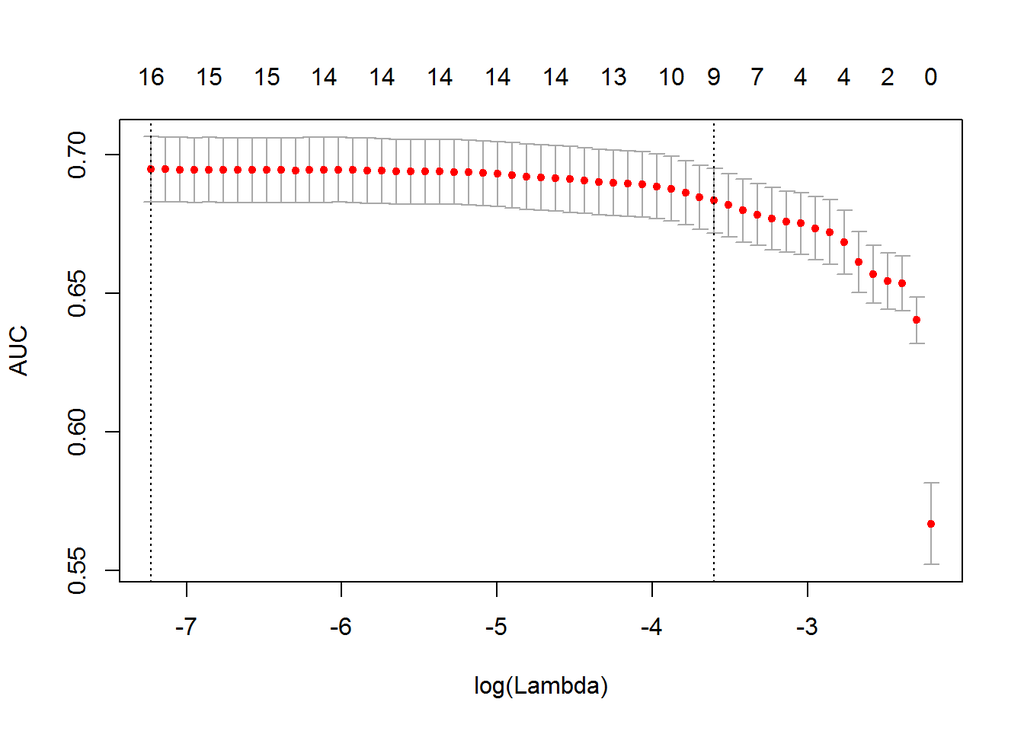

```r
cvLassoAuc=cv.glmnet(trainIndependentVar,trainDependentVar,family="binomial",
                  alpha=1,nfolds = 10,type.measure="auc")
plot.cv.glmnet(cvLassoAuc)
```

getting the best statistics to compute the error

```r
bestLambda=cvLassoAuc$lambda.1se
summary(cvLassoAuc$lambda.1se)
```

```
##    Min. 1st Qu.  Median    Mean 3rd Qu.    Max.
##  0.0273  0.0273  0.0273  0.0273  0.0273  0.0273
```

```r
pedictCV=predict.cv.glmnet(cvLassoAuc,s=bestLambda,
                        newx = testIndependentVar,type = "response")
confusionMetrics(target = testDependentVar,predicted =pedictCV,threshold = 0.5,k = 16)
```

```
##       AIC       BIC       TPR       TNR       FPR       FNR Precision
##   4298.46   4526.14      0.66      0.61      0.39      0.34      0.63
##       NPV  Accuracy  FMeasure       auc
##      0.64      0.63      0.64      0.70
```

```r
lasso.coef=predict(cvLassoAuc ,type ="coefficients",s=bestLambda )[1:18,]
coef(cvLassoAuc)
```

```
## 18 x 1 sparse Matrix of class "dgCMatrix"
##                       1
## (Intercept)  0.27411590
## (Intercept)  .
## lc           0.06448678
## idpyes       0.02392238
## lpi          .
## fmde         .
## physlimyes  -0.05313433
## ndisease    -0.03342898
## healthgood   .
## healthfair  -0.18833960
## healthpoor   .
## linc        -0.03412118
## lfam         .
## educdec      .
## age          .
## sexfemale   -0.11548614
## childyes     0.58125890
## blackno      0.37841215
```

Model for the regression , ridge regression

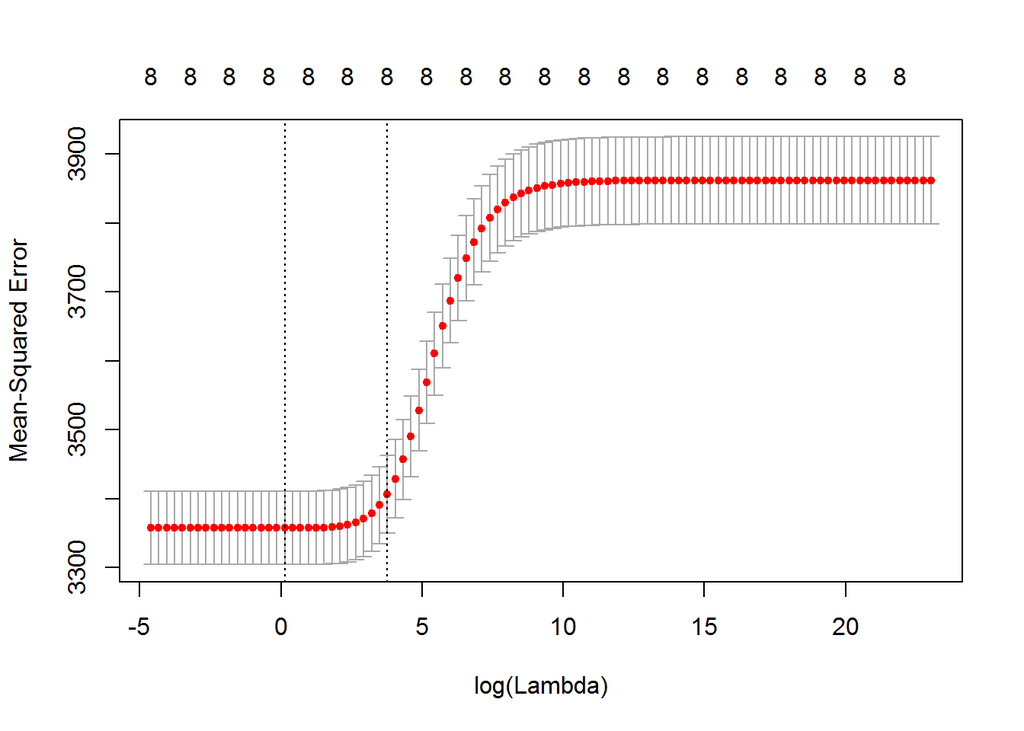

```r
x=MedExp$med
x=ifelse(MedExp$med>mean(MedExp$med),mean(MedExp$med),MedExp$med)
independentVar=model.matrix(med~ndisease+age+sex+physlim+linc+health,data = MedExp)
Lgrid=10^seq(10,-2,length=100)
glmCVRidge=cv.glmnet(independentVar,x,alpha = 0,lambda = Lgrid)
plot(glmCVRidge)
```

```r
glmCVRidge$lambda[100]
```

```
## [1] 0.01
```

```r
bestLambda=glmCVRidge$lambda.min
coef(glmCVRidge)[,bestLambda]
```

```
## (Intercept) (Intercept)    ndisease         age   sexfemale  physlimyes
##   1.7247666   0.0000000   0.9953455   0.4713095   7.4860242   9.0953035
##        linc  healthgood  healthfair  healthpoor
##   2.9106196   3.1648188   8.2269432  17.9486824
```

```r
medPolyglm=glm(medCategory~age+lc+idp+idp+fmde+physlim+ndisease+health+linc+lfam+educdec+sex+child+black,
               data=MedExp,subset =split[split==TRUE],family=binomial)
predictActual=predict(medPolyglm,newdata =MedExpValid,type="response")
table(MedExpValid$medCategory,predictActual>0.3)
```

```
##
##     FALSE TRUE
##   0   410 1262
##   1   109 1563
```

```r
confusionMetrics(MedExpValid$medCategory,predictActual,threshold = 0.3,k = 19)
```

```
##       AIC       BIC       TPR       TNR       FPR       FNR Precision
##   4162.69   4433.06      0.93      0.25      0.75      0.07      0.55
##       NPV  Accuracy  FMeasure       auc
##      0.79      0.59      0.70      0.71
```